# Clustering with Simulated Annealing

```python
import pandas as pd
import numpy as np
import simulatedannealing

import plotly
import plotly.graph_objs as go
import matplotlib.pyplot as plt

from functools import reduce, partial

plotly.offline.init_notebook_mode()
```

## Data Setup

First, we set up a dataframe. The dataframe has 3 different bivariate normal distributions in it. The classes are labelled, and plotted below.

```python
np.random.seed(73)
data = pd.DataFrame({
    'a':reduce(lambda x, y: np.append(x, y),[
            np.random.normal(loc=3, scale=1, size=25),
            np.random.normal(loc=1, scale=1, size=25),
            np.random.normal(loc=5, scale=1, size=25)]),

    'b':reduce(lambda x, y: np.append(x, y),[
            np.random.normal(loc=2, scale=1.2, size=25),
            np.random.normal(loc=4, scale=1.2, size=25),
            np.random.normal(loc=4, scale=1.2, size=25)]),
    'class':[0] * 25 + [1] * 25 + [2] * 25
}, index=range(75))

tracelist = [go.Scatter(
    x = data['a'][data['class'] == i],
    y = data['b'][data['class'] == i],
    mode = 'markers',
    name = f'Class {i}'
) for i in range(3)]


fig = go.Figure(tracelist)
plotly.offline.iplot(fig)
```

[interactive chart not shown]

## Clustering

The idea here is that the algorithm won't know which distribution the data points come from, but will cluster them based on their X and Y positions.

## Optimization

You might be wondering where the optimization problem is here. Suppose there are $K$ clusters (in our case, there are 3, which we know in advance). If we assign all the data points to a cluster, each cluster has a mean value. (In this case, each cluster $C$ has a center $\left(\frac{\sum_{x \in C} x_i}{|C|}, \frac{\sum_{y \in C} y_i}{|C|}\right)$, or the mean $x$ and mean $y$ value for all the points in the cluster.

We can measure the goodness-of-fit for the cluster by measuring the Euclidean distance between the cluster center and all the points in the cluster. We simply sum these distances over all the points. To make this formal, let $\bf{C}$ be a suggested arrangement of all the points into all the clusters, where the $i^{th}$ cluster is denote by $C_i$, and the cluster center for the $i^{th}$ cluster is denoted by $z_i$. Thus, we write $$ M(\bf{C}) = \sum_{i=1}^K \sum_{x_j \in C_i} \vert\vert x_j - z_i \vert\vert. $$

We seek to minimize $M(\bf{C})$ over all the possible arrangement of points into clusters.

# Implementation

First, we implement the function that we seek to optimize. We encode it as a function of the data and the clusters. We then use a lambda function to deploy the calculation against the data created above.

```python
def cluster_fit(x, y, clusters):
    assert isinstance(clusters, np.ndarray)
    dist = 0.0
    for i in range(max(clusters) + 1):
        if np.sum(clusters == i) > 0:
            x_dist = (x[clusters == i] - np.mean(x[clusters == i])) ** 2
            y_dist = (y[clusters == i] - np.mean(y[clusters == i])) ** 2
            dist += np.sum(np.sqrt(x_dist + y_dist))
    return dist

f = lambda cluster: cluster_fit(data['a'].values, data['b'].values,
                                clusters=cluster)
```

Next, we define the `Neighbor` object that we created to generate solutions that are near the current solution. We also assign $K=3$ to be the number of clusters to use.

```python
K = 3
neighbor = simulatedannealing.Neighbor(states=3, n_states=75)
```

We create the `Annealer` object. We set $\alpha=.6$, $\beta(x) = 2x$, the number of changes to make on each iteration equal to 2, $\epsilon=.3$ and the starting number of iterations, $m_0=100$. We also pass in our neighbor object from above. (I fooled around with the parameterization to see how long to run it before the solution converged.)

```python
simann = simulatedannealing.Annealer(f=f, alpha=.6, beta=lambda x: x*2,
                            n_changes=2, epsilon=.3, m0=100, neighbor=neighbor)
```

Next, we run the annealer. We pass it a starting vector that randomly assigned the 3 classes.

```python
solution = simann.run(np.random.choice([0, 1, 2] * 25, 75))
```

```
Running 100 Iterations
Current Temperature: 100
Best Solution: 145.6401956112392
Running 200 Iterations
Current Temperature: 60.0
Best Solution: 145.6401956112392
Running 400 Iterations
Current Temperature: 36.0
Best Solution: 145.6401956112392
Running 800 Iterations
Current Temperature: 21.599999999999998
Best Solution: 145.6401956112392
Running 1600 Iterations
Current Temperature: 12.959999999999999
Best Solution: 145.6401956112392
Running 3200 Iterations
Current Temperature: 7.775999999999999
Best Solution: 142.41946507285746
Running 6400 Iterations
Current Temperature: 4.6655999999999995
Best Solution: 142.41946507285746
Running 12800 Iterations
Current Temperature: 2.7993599999999996
Best Solution: 136.33464622663791
Running 25600 Iterations
Current Temperature: 1.6796159999999998
Best Solution: 123.06796388048609
Running 51200 Iterations
Current Temperature: 1.0077695999999998
Best Solution: 94.89353740034011
Running 102400 Iterations
Current Temperature: 0.6046617599999998
Best Solution: 87.31748059435725
Running 204800 Iterations
Current Temperature: 0.3627970559999999
Best Solution: 86.94143840000542
```

We plot the solution given below. The clusters given are more organized than the correct clusters, but the ones return by the algorithm are organized such to minimize the distance from the center. The optimization algorithm works well.

```python
tracelist = [go.Scatter(
    x = data['a'][solution == i],
    y = data['b'][solution == i],
    mode = 'markers',
    name = f'Class {i}'
) for i in range(3)]

fig = go.Figure(tracelist)
plotly.offline.iplot(fig)
```

[interactive chart not shown]

# Clustering Colors

Next, we apply our algorithm to the clustering of pixels in a picture, based on their colors. The idea is that we can reduce the colors in a painting to a smaller set of more "atomic" colors. By increasing the number of clusters, we can increase the resemblance to the original painting. By decreasing the number of clusters, we can simplify the painting down to a simpler color scheme.

We use a painting with several prominent colors.

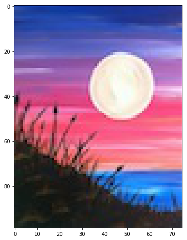

```python
np.random.seed(73)
image = plt.imread("../painting.jpg")
fig, ax = plt.subplots(figsize=(14, 8))
ax.imshow(image)
```

Next, we transform this into a set of observations in $\mathbb{R}^3$, corresponding to the RGB value of each pixel.

```python
image_data = pd.DataFrame(image.reshape(-1, 3), columns=['R', 'G', 'B'])
image_data.head()
```

|  | R | G | B |
| --- | --- | --- | --- |
| 0 | 37 | 76 | 177 |
| 1 | 33 | 75 | 175 |
| 2 | 29 | 72 | 176 |
| 3 | 24 | 68 | 173 |
| 4 | 21 | 68 | 174 |

## Distance Function

```python
def cluster_fit(x, y, z, clusters):
    assert isinstance(clusters, np.ndarray)
    dist = 0.0
    for i in range(max(clusters) + 1):
        if np.sum(clusters == i) > 0:
            x_dist = (x[clusters == i] - np.mean(x[clusters == i])) ** 2
            y_dist = (y[clusters == i] - np.mean(y[clusters == i])) ** 2
            z_dist = (z[clusters == i] - np.mean(z[clusters == i])) ** 2
            dist += np.sum(np.sqrt(x_dist + y_dist))
    return dist

f = lambda cluster: cluster_fit(image_data['R'].values,
                                image_data['G'].values,
                                image_data['B'].values,
                                clusters=cluster)
```

We create our neighbor object and set out number of clusters to 4.

```python
K = 4
n = image_data.shape[0]
neighbor = simulatedannealing.Neighbor(states=K, n_states=n)
```

We create the `Annealer` object. Our dataset is much larger, so we're going to try to get away with less iterations here.

```python
simann = simulatedannealing.Annealer(f=f, alpha=.5, beta=lambda x: x * 2,
                                     n_changes=10, epsilon=1, m0=100,
                                     neighbor=neighbor, verbose=False)

theta0 = np.random.choice(list(range(K)), size=n, replace=True)
image_solution = simann.run(theta0)
```

```
Running 100 Iterations
Current Temperature: 100
Best Solution: 729828.0740408043
Running 200 Iterations
Current Temperature: 50.0
Best Solution: 729708.9637497147
Running 400 Iterations
Current Temperature: 25.0
Best Solution: 729258.7316738814
Running 800 Iterations
Current Temperature: 12.5
Best Solution: 727389.6747317129
Running 1600 Iterations
Current Temperature: 6.25
Best Solution: 716737.3333276266
Running 3200 Iterations
Current Temperature: 3.125
Best Solution: 674220.5544515129
Running 6400 Iterations
Current Temperature: 1.5625
Best Solution: 576305.8893154018
```

## Original Picture

Next, we assign each pixel to its cluster mean, and plot the image.

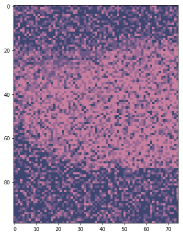

```python
image_data['cluster'] = image_solution
mapped = (np.array(image_data.groupby('cluster').transform(np.mean)).reshape(image.shape)).astype('int')

fig, ax = plt.subplots(figsize=(14, 8))
ax.imshow(mapped)
```

The image is not at all clear. This means that either we did not let it run for enough iterations, or we need more clusters.

## Next Attempt

We try again below, using 6 clusters and running for more iterations. It's worth noting that in the above simulation, the value of the objective function did not appear to converge, so more iterations are likely needed.

```python
K = 6
n = image_data.shape[0]
neighbor = simulatedannealing.Neighbor(states=K, n_states=n)
simann = simulatedannealing.Annealer(f=f, alpha=.6, beta=lambda x: x * 2,
                                     n_changes=10, epsilon=1, m0=100,
                                     neighbor=neighbor, verbose=False)

theta0 = np.random.choice(list(range(K)), size=n, replace=True)
image_solution = simann.run(theta0)
```

```
Running 100 Iterations
Current Temperature: 100
Best Solution: 729927.0200312088
Running 200 Iterations
Current Temperature: 60.0
Best Solution: 729851.6277819965
Running 400 Iterations
Current Temperature: 36.0
Best Solution: 729818.0099522128
Running 800 Iterations
Current Temperature: 21.599999999999998
Best Solution: 729516.6120069474
Running 1600 Iterations
Current Temperature: 12.959999999999999
Best Solution: 726152.0576672556
Running 3200 Iterations
Current Temperature: 7.775999999999999
Best Solution: 696032.7773910394
Running 6400 Iterations
Current Temperature: 4.6655999999999995
Best Solution: 602276.8184944987
Running 12800 Iterations
Current Temperature: 2.7993599999999996
Best Solution: 448573.6209842727
Running 25600 Iterations
Current Temperature: 1.6796159999999998
Best Solution: 317986.9971347281
Running 51200 Iterations
Current Temperature: 1.0077695999999998
Best Solution: 224328.53065935825
```

## Original Picture

We map the colors to their clusters and show the original picture.

[figure not shown]

```python
image_data['cluster'] = image_solution
mapped = (np.array(image_data.groupby('cluster').transform(np.mean)).reshape(image.shape)).astype('int')

fig = plt.figure(figsize=(14, 8))
ax = fig.add_subplot(121)
ax.imshow(mapped)
ax = fig.add_subplot(122)
ax.imshow(image)
```

We can see that the alogrithm worked pretty well here. Most of the pixels are very close to their correct cluster, and the clusters are well defined where one would expect them to be - 6 colors that well represent the image.

This is a cool visual way to inspect a clustering algorithm, as the discrepancies between the original and recreated picture are drawn from two places:

1. The discretization of the number of colors to a lower number.
2. The ability of the algorithm to classify colors correctly within the smaller discrete space.

Here, the colors available seem about right. We have black, 2 blues, and 3 pink/purples. This allows us to generally outline the picture well. There are several misclassified points, which can be seen easily above (for example, the moon features several blue and dark pink pixels). But on the whole, the algorithm recreates the picture well, and we can see the original outline.